← retour à la galerie

```python
import numpy as np
from matplotlib import pyplot as plt
import math
from IPython.display import Image
from numpy.polynomial.polynomial import Polynomial
from numpy.polynomial import Polynomial as P
from numpy.polynomial import Chebyshev
import ephem
```

# Calcul des éphémérides par interpolation des polynomes de Tchebychev

Le calcul des éphémérides est depuis longtemps assuré par des méthodes puissantes et dont l'erreur est assez faible. Un premier pas dans ce large domaine est d'essayer d'interpoler la trajectoire de certains astres grâce aux polynômes de Tchebychev de première espèce. Cette famille de polynômes est notamment découverte par tous les élèves de classe préparatoire scientifiques. On s'intérésse donc à une application concrète de ce que l'on découvre en classe.

Dans le cadre des éphémérides, l'approximation lagrangienne (plus classique dans le cas général) par des polynômes consiste à faire passer, pour un intervalle donné, un polynôme de degré n par n+1 valeurs, alors qu'il serait préférable de tenir compte de toutes les valeurs de la fonction sur cet intervalle. L'approximation de Tchebychev s'impose pour cela, car elle est celle de plus bas degré dont l'erreur ne dépasse pas une valeur donnée a priori, et son erreur est régulièrement distribuée sur l'intervalle considéré.

## Revue rapide des polynômes de Tchebychev

On peut définir les polynômes de Tchebychev de première espèce par : $$T_n(x)= \cos (n \arccos(x))$$ On montre par la suite les propriétés suivantes :

- i : Les polynômes de Tchebychev sont uniques
- ii : Ils vérifient la relation de récurrence : $\forall n \ge 2, \forall X \in [-1,1], T_{n+2}(X)=2X T_{n+1}-T_n (X)$
- iii : $\forall n \ge 2, deg(T_n)=n$ et il est de coefficient dominant $2^{n-1}$
- iv : On définit $\forall k \ \{0,... n-1 \}, \theta_k= \frac {(2k+1)\pi} {2n}$ de sorte que $( \cos(\theta_k))_k$ forme la famille des n racines distinctes du polynome $T_n$

De plus, l'intetêt vis à vis de ces polynômes vient du faite qu'ils forment une famille orthogonale de $ \mathbb R [X]$ pour le produit scalaire suivant : $$\forall P,Q \in \mathbb R [X], \langle P,Q \rangle = \int_{-1}^1 \frac {P(t) Q(t)}{\sqrt{1-t^2}} dt $$

En pratique, disposer d'une famille orthogonal est la clée pour exprimer un vecteur. S'il on dispose d'un vecteur (ici un polynome), on peut l'exprimer comme une combinaison linéaire des vecteurs de la base orthogonale (ici les $T_n$).

### Définition de l'interpolation

Grossièrement, interpoler c'est trouver la trajectoire la plus cohérente en disposant d'une certains nombre de points. Pour mieux comprendre, intéréssons nous à une interpolation simple par les polynômes de Lagrange

Nous disposons des points suivants :

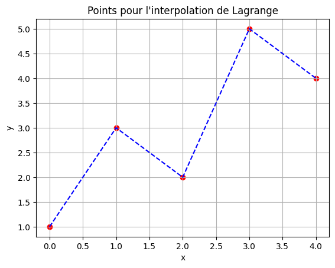

```python
# Liste de points (x, y)
points = [(0, 1), (1, 3), (2, 2), (3, 5), (4, 4)]

# Séparer les points en deux listes : x et y
x_points, y_points = zip(*points)

# Afficher les points dans un plot
plt.scatter(x_points, y_points, color='red')
plt.plot(x_points, y_points, linestyle='dashed', color='blue')
plt.title('Points pour l\'interpolation de Lagrange')
plt.xlabel('x')
plt.ylabel('y')
plt.grid(True)
plt.show()
```

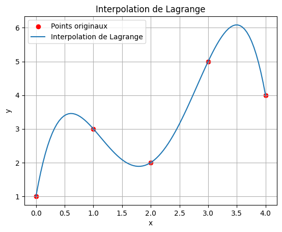

```python
# Fonction pour calculer l'interpolation de Lagrange
def lagrange_interpolation(x_points, y_points):
    poly = P([0.0])
    n = len(x_points)
    for i in range(n):
        p = P([1.0])
        for j in range(n):
            if i != j:
                p *= P([-x_points[j], 1.0]) / (x_points[i] - x_points[j])
        poly += p * y_points[i]
    return poly

# Calculer le polynôme d'interpolation
lagrange_poly = lagrange_interpolation(x_points, y_points)

# Afficher le polynôme d'interpolation
x_new = np.linspace(min(x_points), max(x_points), 100)
y_new = lagrange_poly(x_new)

plt.scatter(x_points, y_points, color='red', label='Points originaux')
plt.plot(x_new, y_new, label='Interpolation de Lagrange')
plt.title('Interpolation de Lagrange')
plt.xlabel('x')
plt.ylabel('y')
plt.legend()
plt.grid(True)
plt.show()
```